# Homework 2 Analytical Tasks

Author

Davis Johnson

## Analytical Tasks

```r
# loading prep data

load("~/Downloads/movie_aggregated.RData")
load("~/Downloads/movie_combined.RData")
```

1. Which genre (I’m assuming average for each genre) has the highest critic rating? Viewer rating?

```r
# subset data to only include rows including critic reviews

critic_ratings <- movie_combined %>%
  filter(movie_combined$reviewer_type == "Critic")


# creating table that calculates mean critic reviews grouped by genre

critic_table <- critic_ratings %>%
  group_by(genre) %>%
  summarise(AvgCriticRating = mean(rating_first_watch)) %>%
  arrange(desc(AvgCriticRating))

# creating paged table of above table

rmarkdown::paged_table(critic_table)
```

| genre | AvgCriticRating |
| --- | --- |
| Comedy | 3.015000 |
| Drama | 2.869512 |
| Romance | 2.616667 |
| Horror | 2.500000 |
| Action/Adventure | 2.385366 |
| Sci-Fi | 2.311765 |
| Other | 2.305882 |
| Kids | 2.200000 |

###### Comedy has the highest average critic ratings.

```r
# subset data to only include rows with viewer reviews

viewer_ratings <- movie_combined %>%
  filter(reviewer_type == "Viewer")

# creating table that calculates mean viewer reviews grouped by genre

viewer_table <- viewer_ratings %>%
  group_by(genre) %>%
  summarise(AvgViewerRating = mean(rating_first_watch)) %>%
  arrange(desc(AvgViewerRating))

# creating paged table of above table

rmarkdown::paged_table(viewer_table)
```

| genre | AvgViewerRating |
| --- | --- |
| Comedy | 3.566216 |
| Drama | 3.555046 |
| Romance | 3.156923 |
| Horror | 3.116216 |
| Other | 3.077778 |
| Action/Adventure | 3.000985 |
| Sci-Fi | 2.902857 |
| Kids | 2.766102 |

###### Comedy also has the highest average rating among viewers.

2. What is the relationship between movie length and average rating?

```r
# creating subset from movie_combined that only includes unique movie title values

movie_combined_subset <- movie_combined[!duplicated(movie_combined[c("title")]), ]

# binding total_length column to aggregated dataset

movie_agg_new <- cbind(movie_agg, total_length_mins = movie_combined_subset$total_length_mins)
```

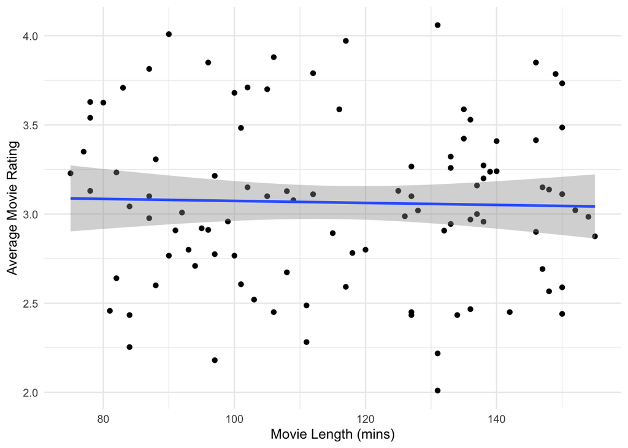

```r
# creating scatter plot to analyze relationship between movie length and average movie rating for each movie


library(ggplot2)


ggplot(movie_agg_new, aes(x = total_length_mins, y = rating_first_watch)) +
  geom_point() +
  geom_smooth(method = 'lm') +
  theme_minimal() +
  labs(x = "Movie Length (mins)",
       y = "Average Movie Rating")
```

###### There is no relationship between movie length and average movie rating.

3. What is the relationship between the date delta and average rating?

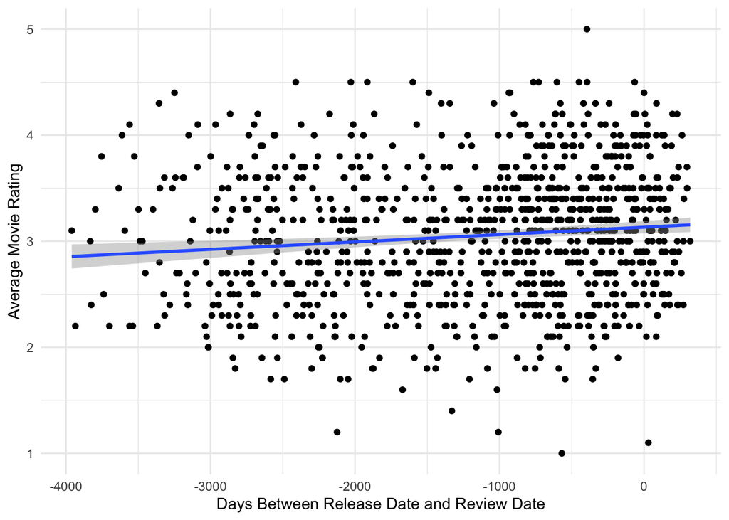

```r
# creating scatter plot to analyze relationship between date delta and average movie rating for each movie

ggplot(movie_combined, aes(x = date_delta, y = rating_first_watch)) +
  geom_point() +
  geom_smooth(method = "lm") +
  theme_minimal() +
  labs(x = "Days Between Release Date and Review Date",
       y = "Average Movie Rating")
```

###### There is a slightly positive relationshsip between date delta and movie rating. Most reviews are made close to the movie’s release date.

4. What is the relationship between total number of reviews and average?

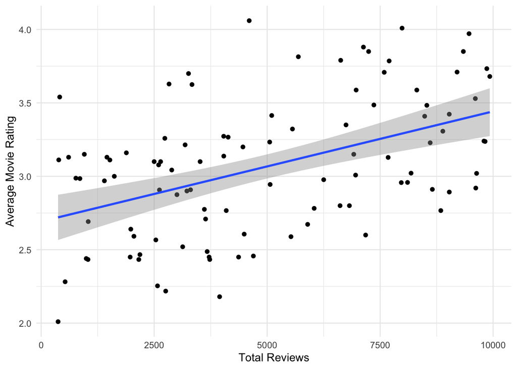

```r
# creating scatter plot to compare total reviews with average movie rating for each movie

ggplot(movie_agg, aes(x = total_reviews, y = rating_first_watch)) +
  geom_point() +
  geom_smooth(method = "lm") +
  theme_minimal() +
  labs(x = "Total Reviews",
       y = "Average Movie Rating")
```

###### There appears to be a positive correlation between the total number of reviews and the average rating for each movie.

5. Which movie contains your word of interest at the highest frequency. Does that word have any relationship with average rating?

```r
# creating paged table that counts the total number of times love appears across all reviews for each movie

rmarkdown::paged_table(
  head(
    movie_combined %>%
  group_by(title) %>%
  summarise(total_love_count = sum(feel_the_love)) %>%
  arrange(desc(total_love_count)), 3
  )
  )
```

| title | total_love_count |
| --- | --- |
| Lost Treasures | 2 |
| Love in the Air | 2 |
| The Last Crusade | 2 |

###### The three movies above have reviews that contain the most total amounts of the word “love.”

```r
# filtering data to only include rows where the review contains "love"

positive_love_count <- movie_combined %>%
  filter(feel_the_love > 0)

# filtering data to only include rows where "love" does not appear

zero_love_count <- movie_combined  %>%
  filter(feel_the_love == 0)

# creating two variables that contain the average rating for reviews containing and not containing "love"

average_rating_positive_love <- mean(positive_love_count$rating_first_watch)
average_rating_zero_love <- mean(zero_love_count$rating_first_watch)

# creating paged table that compares the average reviews for movies that have reviews containing "love" versus those that don't

summary_table <- data.frame(
  Category = c("Total Love Count > 0", "Total Love Count = 0"),
  AverageRating = c(average_rating_positive_love, average_rating_zero_love)
)

rmarkdown::paged_table(summary_table)
```

| Category | AverageRating |
| --- | --- |
| Total Love Count > 0 | 3.20000 |
| Total Love Count = 0 | 3.04759 |

###### Based on the calculation above, ratings of movies that contain reviews with the word “love” have slightly higher ratings than movie ratings with reviews that don’t contain the word “love” on average. However, it is important to note that in this data set, there are a lot more movie reviews that don’t contain the word “love” than those that do.